# Week 1: A bird’s-eye view of a single-cell workflow

Kevin Z. Lin

2026-07-27

# 1 Overview

This tutorial runs a complete single-cell analysis end to end, from a raw count matrix to a UMAP with cell clusters, using **Seurat’s default settings at every step**. The goal is not to make good choices yet — it is to see the whole skeleton at once, so that when we spend a full session on any one step you already know where it sits in the pipeline and what it is supposed to accomplish.

The dataset is the 10x Genomics PBMC demonstration data (peripheral blood mononuclear cells, ~2,700 cells). It is small, clean, and well annotated, which makes it a good scaffold. Your own data will be messier.

The workflow has six conceptual stages:

| Stage | Question it answers | Seurat function |
| --- | --- | --- |
| Load | What did the sequencer actually give me? | `Read10X`, `CreateSeuratObject` |
| Quality control | Which barcodes are real, healthy cells? | `PercentageFeatureSet`, `subset` |
| Normalization | How do I compare a cell with 10,000 counts to one with 1,000? | `NormalizeData` |
| Feature selection | Which genes carry the biological signal? | `FindVariableFeatures` |
| Dimension reduction | How do I compress 2,000 genes into a few axes? | `ScaleData`, `RunPCA` |
| Clustering & visualization | Which cells belong together, and what does that look like? | `FindNeighbors`, `FindClusters`, `RunUMAP` |

Reference material: the [Seurat essential commands](https://satijalab.org/seurat/articles/seurat5_essential_commands) and the [Seurat guided clustering tutorial](https://satijalab.org/seurat/articles/pbmc3k_tutorial), which this tutorial closely follows.

# 2 Setting up the Seurat object

## 2.1 Loading the counts

`Read10X()` reads the three-file output of Cell Ranger (a barcode list, a feature list, and a sparse matrix) and returns a genes × cells matrix of UMI counts. Entry $(i,j)$ is the number of distinct mRNA molecules from gene $i$ detected in cell $j$.

You can download the data from https://www.dropbox.com/scl/fi/9mn6q4clnjobfdsmpgshs/seurat-pbmc.zip?rlkey=z4ha1mdwcsoew6o712ciwfq5i&dl=0.

```r
rm(list=ls())
library(Seurat)
pbmc.data <- Seurat::Read10X(data.dir = "/Users/kevinlin/Library/CloudStorage/Dropbox/Collaboration-and-People/sumie-katie/data/seurat-pbmc/filtered_feature_bc_matrix")
```

## 2.2 Creating the object

A `Seurat` object is a container. It holds the data (count matrices), the per-cell annotations (metadata), and the results of every analysis you run (PCA, clusters, UMAP). Everything downstream is “take the object, add something to it, hand it back” — which is why nearly every line below is `pbmc <- Something(pbmc, ...)`.

```r
pbmc <- Seurat::CreateSeuratObject(counts = pbmc.data,
                                   project = "pbmc3k")
pbmc
```

```
## An object of class Seurat
## 32738 features across 2700 samples within 1 assay
## Active assay: RNA (32738 features, 0 variable features)
##  1 layer present: counts
```

The printout tells you the two numbers that matter most: how many features (genes) and how many samples (cells) you have.

## 2.3 Looking inside the object

Cell-level metadata is a data frame with one row per cell. Seurat starts you off with the total counts per cell (`nCount_RNA`) and the number of genes detected per cell (`nFeature_RNA`). This table is where QC metrics, cluster labels, and sample annotations accumulate as you go.

```r
head(pbmc@meta.data)
```

```
##                  orig.ident nCount_RNA nFeature_RNA
## AAACATACAACCAC-1     pbmc3k       2421          781
## AAACATTGAGCTAC-1     pbmc3k       4903         1352
## AAACATTGATCAGC-1     pbmc3k       3149         1131
## AAACCGTGCTTCCG-1     pbmc3k       2639          960
## AAACCGTGTATGCG-1     pbmc3k        981          522
## AAACGCACTGGTAC-1     pbmc3k       2164          782
```

The count matrix itself is a sparse matrix — the vast majority of entries are zero, so R stores only the non-zeros. It still behaves like an ordinary matrix for indexing and arithmetic.

```r
count_mat <- SeuratObject::LayerData(pbmc,
                                     layer = "counts",
                                     assay = "RNA")
count_mat[42:44,14:16]
```

```
## 3 x 3 sparse Matrix of class "dgCMatrix"
##              AAAGAGACGCGAGA-1 AAAGAGACGGACTT-1 AAAGAGACGGCATT-1
## RP11-54O7.11                .                .                .
## ISG15                       5                .                2
## AGRN                        .                .                .
```

```r
head(colSums(count_mat))
```

```
## AAACATACAACCAC-1 AAACATTGAGCTAC-1 AAACATTGATCAGC-1 AAACCGTGCTTCCG-1
##             2421             4903             3149             2639
## AAACCGTGTATGCG-1 AAACGCACTGGTAC-1
##              981             2164
```

```r
head(pbmc$nCount_RNA)
```

```
## AAACATACAACCAC-1 AAACATTGAGCTAC-1 AAACATTGATCAGC-1 AAACCGTGCTTCCG-1
##             2421             4903             3149             2639
## AAACCGTGTATGCG-1 AAACGCACTGGTAC-1
##              981             2164
```

Note that the last two lines agree: `nCount_RNA` is simply the column sums of the count matrix. Metadata columns are bookkeeping, not new information.

Gene names and cell names are accessible directly:

```r
SeuratObject::Features(pbmc)[1:5]
```

```
## [1] "MIR1302-10"   "FAM138A"      "OR4F5"        "RP11-34P13.7" "RP11-34P13.8"
```

```r
Seurat::Cells(pbmc)[1:5]
```

```
## [1] "AAACATACAACCAC-1" "AAACATTGAGCTAC-1" "AAACATTGATCAGC-1" "AAACCGTGCTTCCG-1"
## [5] "AAACCGTGTATGCG-1"
```

# 3 Quality control

Not every barcode in the matrix is a healthy single cell. Some are empty droplets that caught only ambient RNA, some are dying cells leaking cytoplasm, some are two cells captured together. QC is the step where we compute a few per-cell summary statistics and use them to decide what to keep.

## 3.1 Mitochondrial fraction

When a cell’s membrane ruptures, cytoplasmic mRNA escapes but mitochondria-encoded transcripts stay behind. A high fraction of mitochondrial counts is therefore a signature of a stressed or dying cell. In human data these genes are the ones prefixed `MT-`.

`PercentageFeatureSet()` computes, per cell, the percent of counts falling in a matching set of genes, and the `[[` assignment stashes it in the metadata.

```r
gene_vec <- SeuratObject::Features(pbmc)
gene_vec[grep("^MT-", gene_vec)]
```

```
##  [1] "MT-ND1"  "MT-ND2"  "MT-CO1"  "MT-CO2"  "MT-ATP8" "MT-ATP6" "MT-CO3"
##  [8] "MT-ND3"  "MT-ND4L" "MT-ND4"  "MT-ND5"  "MT-ND6"  "MT-CYB"
```

```r
pbmc[["percent.mt"]] <- Seurat::PercentageFeatureSet(pbmc,
                                                     pattern = "^MT-")
```

## 3.2 Ribosomal fraction

The same machinery applied to ribosomal protein genes. Cells dominated by ribosomal transcripts often have little else going on, and the ribosomal fraction can vary systematically across cell types — it is worth computing and looking at, even if you do not filter on it.

```r
gene_vec[grep("^RPS", gene_vec)]
```

```
##  [1] "RPS6KA1"     "RPS8"        "RPS27"       "RPS10P7"     "RPS6KC1"
##  [6] "RPS7"        "RPS27A"      "RPSA"        "RPS3A"       "RPS23"
## [11] "RPS14"       "RPS18"       "RPS10-NUDT3" "RPS10"       "RPS12"
## [16] "RPS6KA2"     "RPS6KA2-AS1" "RPS6KA3"     "RPS4X"       "RPS6KA6"
## [21] "RPS20"       "RPS6"        "RPS24"       "RPS13"       "RPS6KA4"
## [26] "RPS6KB2"     "RPS3"        "RPS25"       "RPS26"       "RPS29"
## [31] "RPS6KL1"     "RPS6KA5"     "RPS27L"      "RPS17"       "RPS17L"
## [36] "RPS2"        "RPS15A"      "RPS6KB1"     "RPS21"       "RPS15"
## [41] "RPS28"       "RPSAP58"     "RPS16"       "RPS19"       "RPS11"
## [46] "RPS9"        "RPS5"        "RPS4Y1"      "RPS4Y2"      "RPS19BP1"
```

```r
pbmc[["percent.rb"]] <- Seurat::PercentageFeatureSet(pbmc,
                                                     pattern = "^RPS")
```

## 3.3 Cell cycle scores

Proliferating cells express a coherent program of S-phase and G2/M genes. That program is real biology, but it is usually not the biology you care about, and it is strong enough to drive clustering on its own. Scoring it lets you check whether it is a problem for your data.

`CellCycleScoring()` needs normalized values rather than raw counts, so we call `NormalizeData()` here to fill that slot. We will call it again later, after filtering — that repeat is intentional, not a mistake. See the [cell cycle vignette](https://satijalab.org/seurat/articles/cell_cycle_vignette.html) for what to do if the cycle turns out to dominate.

```r
pbmc <- Seurat::NormalizeData(pbmc)
s.genes <- cc.genes$s.genes
g2m.genes <- cc.genes$g2m.genes
pbmc <- Seurat::CellCycleScoring(pbmc,
                                 s.features = s.genes,
                                 g2m.features = g2m.genes)
```

Everything we computed now lives alongside the original metadata:

```r
head(pbmc@meta.data)
```

```
##                  orig.ident nCount_RNA nFeature_RNA percent.mt percent.rb
## AAACATACAACCAC-1     pbmc3k       2421          781  3.0152829  18.917803
## AAACATTGAGCTAC-1     pbmc3k       4903         1352  3.7935958  18.417296
## AAACATTGATCAGC-1     pbmc3k       3149         1131  0.8891712  13.623372
## AAACCGTGCTTCCG-1     pbmc3k       2639          960  1.7430845   9.170140
## AAACCGTGTATGCG-1     pbmc3k        981          522  1.2232416   4.689093
## AAACGCACTGGTAC-1     pbmc3k       2164          782  1.6635860  13.909427
##                      S.Score    G2M.Score Phase
## AAACATACAACCAC-1  0.07721641 -0.027546191     S
## AAACATTGAGCTAC-1 -0.02723808 -0.038481308    G1
## AAACATTGATCAGC-1 -0.01832618  0.069915003   G2M
## AAACCGTGCTTCCG-1  0.01548134  0.008207127     S
## AAACCGTGTATGCG-1 -0.05922341  0.031726222   G2M
## AAACGCACTGGTAC-1 -0.05420895 -0.063251247    G1
```

## 3.4 Visualizing the QC metrics

Always look at the distributions before choosing a threshold. Violin plots show you whether a metric is unimodal (one population, pick a tail cutoff) or has structure (possibly several cell types, in which case a single global cutoff will preferentially delete one of them).

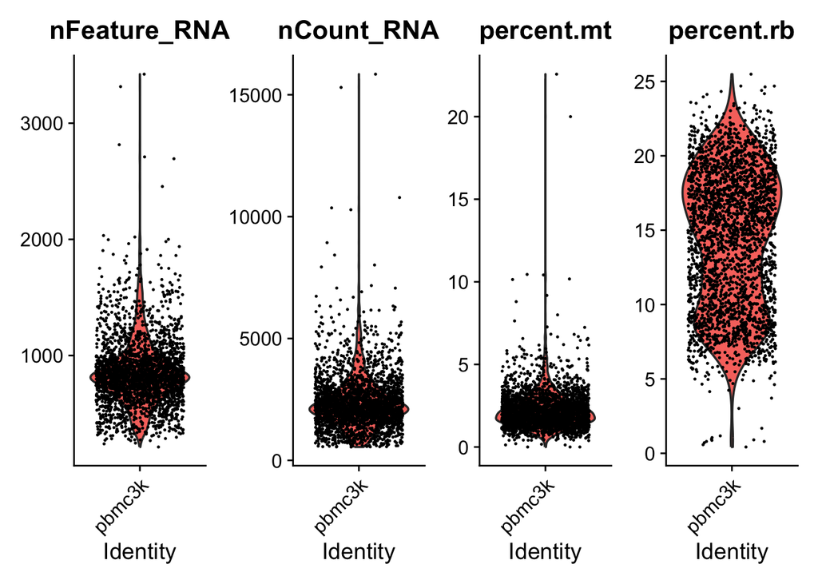

```r
Seurat::VlnPlot(pbmc, features = c("nFeature_RNA",  "nCount_RNA", "percent.mt", "percent.rb"),
                ncol = 4)
```

## 3.5 Filtering

The cutoffs below are the ones from the Seurat tutorial: drop cells with fewer than 200 genes detected (empty or dying), more than 2,500 genes (likely doublets), or more than 5% mitochondrial counts (damaged).

These numbers are conventions, not laws. They were chosen for this dataset, and brain tissue in particular tolerates much higher mitochondrial fractions and yields far fewer genes per nucleus. Copying them onto your own data unexamined is the single most common way to silently throw away a cell type.

```r
pbmc <- subset(pbmc,
               subset = nFeature_RNA > 200 & nFeature_RNA < 2500 & percent.mt < 5)
```

# 4 Normalization

Two cells with identical biology can have very different total counts, purely because of how efficiently each was captured and sequenced. Normalization removes that nuisance variation so that expression is comparable across cells.

Seurat’s default, `LogNormalize`, does three things per cell: divide each count by the cell’s total, multiply by 10,000, and take `log(1 + x)`. The division puts cells on a common scale; the log compresses the very large values so that a handful of highly expressed genes do not dominate every downstream distance calculation.

```r
pbmc <- Seurat::NormalizeData(pbmc)
```

# 5 Feature selection

The complication is that in count data, variance grows with mean — highly expressed genes look variable simply because they are highly expressed. The `vst` method fits that mean–variance trend and ranks genes by how far they exceed it, so “variable” means variable *beyond what its expression level predicts*.

```r
pbmc <- Seurat::FindVariableFeatures(pbmc,
                                     selection.method = "vst",
                                     nfeatures = 2000)
```

The plot below shows every gene by mean expression and standardized variance, with the selected 2,000 in red. The labeled outliers are usually recognizable markers of specific cell types — a quick sanity check that feature selection is picking up biology.

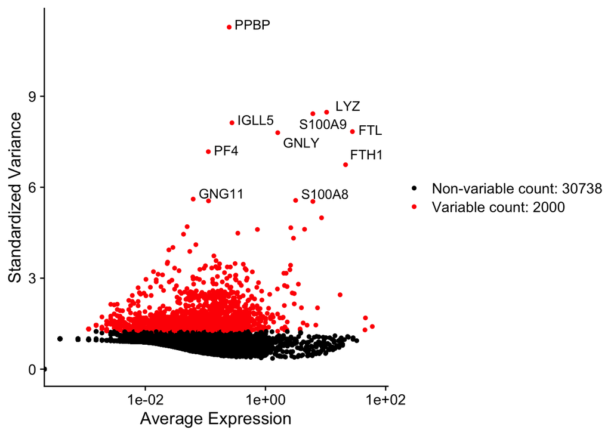

```r
top10 <- head(Seurat::VariableFeatures(pbmc), 10)
plot1 <- Seurat::VariableFeaturePlot(pbmc)
plot1 <- Seurat::LabelPoints(plot = plot1,
                             points = top10,
                             repel = TRUE)
plot1
```

# 6 Dimension reduction

## 6.1 Scaling

Even after normalization, genes differ in absolute expression level by orders of magnitude. PCA maximizes variance, so without further adjustment the highest expressed genes would define the leading components regardless of their biological relevance. `ScaleData()` centers each gene to mean 0 and scales it to variance 1, so every gene gets an equal vote.

```r
pbmc <- Seurat::ScaleData(pbmc)
```

## 6.2 PCA

We now have a ~2,000-dimensional space, which is both too large to compute in comfortably and mostly noise. PCA finds the directions of greatest variation and re-expresses each cell as coordinates along them. In practice the first few dozen components capture the structure — the differences between cell types — while the remainder is largely technical noise.

Each principal component is a weighted combination of genes, so a PC can often be read as a coordinated gene module (for example, a myeloid program).

```r
pbmc <- Seurat::RunPCA(pbmc,
                       features = Seurat::VariableFeatures(object = pbmc),
                       verbose = FALSE)
```

The object now reports a dimensional reduction alongside the assay:

```r
pbmc
```

```
## An object of class Seurat
## 32738 features across 2638 samples within 1 assay
## Active assay: RNA (32738 features, 2000 variable features)
##  3 layers present: counts, data, scale.data
##  1 dimensional reduction calculated: pca
```

# 7 Clustering

Clustering is where “cells” become “cell types”. Seurat does this in two steps.

`FindNeighbors()` builds a graph: each cell is connected to its nearest neighbors in PCA space, with edges weighted by how much their neighborhoods overlap. Note the `dims = 1:10` argument — we are using only the first 10 PCs, discarding the rest as noise.

`FindClusters()` then partitions that graph, looking for groups of cells that are densely connected to each other and sparsely connected to everything else. The `resolution` parameter controls granularity: higher values yield more, finer clusters.

```r
pbmc <- Seurat::FindNeighbors(pbmc,
                              dims = 1:10)
pbmc <- Seurat::FindClusters(pbmc,
                             resolution = 0.5)
```

```
## Modularity Optimizer version 1.3.0 by Ludo Waltman and Nees Jan van Eck
##
## Number of nodes: 2638
## Number of edges: 95888
##
## Running Louvain algorithm...
## Maximum modularity in 10 random starts: 0.8758
## Number of communities: 9
## Elapsed time: 0 seconds
```

The cluster assignment is written back into the metadata, under a name that records the resolution used. This matters: run several resolutions and you get several columns, and you can compare them.

```r
head(pbmc@meta.data)
```

```
##                  orig.ident nCount_RNA nFeature_RNA percent.mt percent.rb
## AAACATACAACCAC-1     pbmc3k       2421          781  3.0152829  18.917803
## AAACATTGAGCTAC-1     pbmc3k       4903         1352  3.7935958  18.417296
## AAACATTGATCAGC-1     pbmc3k       3149         1131  0.8891712  13.623372
## AAACCGTGCTTCCG-1     pbmc3k       2639          960  1.7430845   9.170140
## AAACCGTGTATGCG-1     pbmc3k        981          522  1.2232416   4.689093
## AAACGCACTGGTAC-1     pbmc3k       2164          782  1.6635860  13.909427
##                      S.Score    G2M.Score Phase RNA_snn_res.0.5 seurat_clusters
## AAACATACAACCAC-1  0.07721641 -0.027546191     S               0               0
## AAACATTGAGCTAC-1 -0.02723808 -0.038481308    G1               3               3
## AAACATTGATCAGC-1 -0.01832618  0.069915003   G2M               2               2
## AAACCGTGCTTCCG-1  0.01548134  0.008207127     S               5               5
## AAACCGTGTATGCG-1 -0.05922341  0.031726222   G2M               6               6
## AAACGCACTGGTAC-1 -0.05420895 -0.063251247    G1               2               2
```

# 8 Visualization

UMAP takes the same 10 PCs and finds a two-dimensional arrangement of cells that preserves local neighborhoods as well as it can. It is a *display* technique, not an analysis: clusters are computed in PCA space, and the UMAP just shows them to you.

Read UMAPs with care. Which points sit next to which is meaningful; the distance between two well-separated blobs, the shape of a blob, and the orientation of the plot are not.

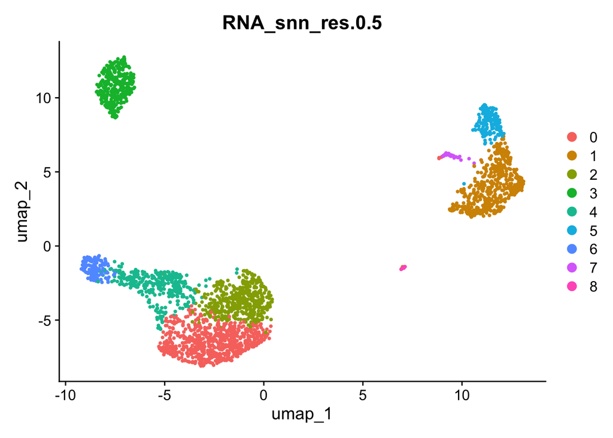

```r
pbmc <- Seurat::RunUMAP(pbmc,
                        dims = 1:10)
plot1 <- Seurat::DimPlot(pbmc,
                reduction = "umap",
                group.by = "RNA_snn_res.0.5")
plot1
```

The finished object carries the full history of the analysis — the counts, the normalized and scaled data, the metadata, and both reductions:

```r
pbmc
```

```
## An object of class Seurat
## 32738 features across 2638 samples within 1 assay
## Active assay: RNA (32738 features, 2000 variable features)
##  3 layers present: counts, data, scale.data
##  2 dimensional reductions calculated: pca, umap
```

# 9 What we glossed over

Every step above ran on a default, and each of those defaults is a decision someone made for a dataset that is not yours. The rest of the workshop is about turning them back into choices:

- **Why 200 and 2,500 genes, and 5% mitochondrial?** Where these cutoffs come from, why nuclei behave differently from cells, and how ambient RNA and doublets produce the patterns we filtered on. Also: where the count matrix itself comes from, since we started by reading one off disk — **Week 2**.
- **Why log-normalize? Why 2,000 variable genes? Why 10 PCs and resolution 0.5?** Alternatives such as `SCTransform` (which replaces `NormalizeData`, `FindVariableFeatures`, and `ScaleData` in one step), how to choose the dimensionality, and how to tell a real cluster from an artifact of the resolution knob — **Week 3**.
- **How do I test anything, and what are these clusters?** Marker genes, case/control comparisons within a cluster, and putting cell type names on the numbered clusters we produced above — **Week 4**.
- **What if the data came from several samples or batches?** Everything above assumes one homogeneous dataset; with multiple samples the clusters can separate by donor rather than by biology. Also bulk deconvolution, for estimating cell type proportions when you only have bulk RNA-seq — **Week 5**.

If you run this script on your own data today and the UMAP looks strange, that is the expected outcome, and it is the material for the next four weeks.